# Fetching elevation data from Mapbox

Miles McBain

2019-06-29

There are some slippy map tile providers that can serve you tiles that represent Digital Elevation Model (DEM) data, rather than map imagery. This is the kind of data you want to make 3D maps with `rayshader` or `quadmesh`. Mapbox have an API for DEM tiles called [Mapbox Terrain-RGB](https://docs.mapbox.com/help/troubleshooting/access-elevation-data/#mapbox-terrain-rgb) that we will use in this example.

## Get a Mapbox API key

Sign up for Mapbox and generate yourself an API access token. For my testing I have used a ‘public’ token with `styles:tiles`. Add that API token to your .Renviron file (in your home directory) as:

```
MAPBOX_API_KEY=<YOUR REALLY LONG TOKEN HERE>
```

## Fetch the RGB tiles for your bounding box

How many tiles?

```r
library(slippymath)

tibrogargan<- c(xmin = 152.938485, ymin = -26.93345, xmax = 152.956467,
               ymax = -26.921463)

slippymath::bbox_tile_query(tibrogargan)
```

```
#>     x_min  y_min  x_max  y_max y_dim x_dim total_tiles zoom
#> 1       3      2      3      2     1     1           1    2
#> 2       7      4      7      4     1     1           1    3
#> 3      14      9     14      9     1     1           1    4
#> 4      29     18     29     18     1     1           1    5
#> 5      59     36     59     36     1     1           1    6
#> 6     118     73    118     73     1     1           1    7
#> 7     236    147    236    147     1     1           1    8
#> 8     473    295    473    295     1     1           1    9
#> 9     947    591    947    591     1     1           1   10
#> 10   1894   1183   1894   1183     1     1           1   11
#> 11   3788   2366   3788   2366     1     1           1   12
#> 12   7576   4732   7576   4732     1     1           1   13
#> 13  15152   9464  15153   9465     2     2           4   14
#> 14  30304  18929  30306  18931     3     3           9   15
#> 15  60609  37859  60612  37862     4     4          16   16
#> 16 121219  75719 121225  75724     6     7          42   17
#> 17 242438 151439 242451 151449    11    14         154   18
```

It’s a small area so we don’t need a lot. 9 tiles as zoom 15 looks good. Let’s get the tile grid.

```r
tibrogargan_grid <- bbox_to_tile_grid(tibrogargan,zoom = 15)
```

Now we’ll fetch the tiles from Mapbox.

```r
library(glue)
library(purrr)
library(curl)

mapbox_query_string <-
paste0("https://api.mapbox.com/v4/mapbox.terrain-rgb/{zoom}/{x}/{y}.jpg90",
       "?access_token=",
       Sys.getenv("MAPBOX_API_KEY"))

tibro_tiles <-
pmap(.l = tibrogargan_grid$tiles,
     zoom = tibrogargan_grid$zoom,

     .f = function(x, y, zoom){
       outfile <- glue("{x}_{y}.jpg")
       curl_download(url = glue(mapbox_query_string),
            destfile = outfile)
       outfile
     }
     )
```

## Stitch tiles into a raster

We composite the images to raster with `compose_tile_grid` and view the raster:

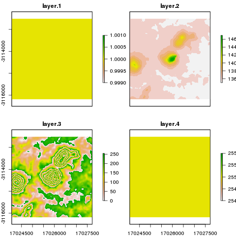

```r
tibrogargan_raster <- slippymath::compose_tile_grid(tibrogargan_grid, tibro_tiles)
raster::plot(tibrogargan_raster)
```

## Converting RGB tiles to DEM tiles

Mapbox provide [a formula](https://docs.mapbox.com/help/troubleshooting/access-elevation-data/#decode-data) to decode the RGB values to elevation. This was implemented in the function below by Michael Sumner.

```r
decode_elevation <- function(dat) {
  height <-  -10000 + ((dat[[1]] * 256 * 256 + dat[[2]] * 256 + dat[[3]]) * 0.1)
  raster::projection(height) <- "+proj=merc +a=6378137 +b=6378137"
  height
}
```

When we apply it to `tibrogargan_raster` we get:

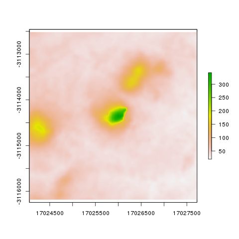

```r
tibrogargan_elevation <- decode_elevation(tibrogargan_raster)
raster::plot(tibrogargan_elevation)
```

## Rendering DEM image

### Rayshader

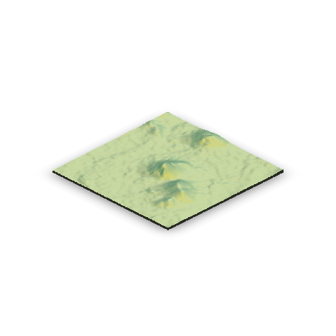

```r
library(magrittr)
library(rayshader)

elevation_mat <- t(raster::as.matrix(tibrogargan_elevation))

shadow_mat <- ray_shade(elevation_mat)

elevation_mat %>%
  sphere_shade(progbar = FALSE, sunangle = 45) %>%
  add_shadow(shadow_mat) %>%
  plot_3d(elevation_mat,
          zscale = 7,
          phi = 30,
          theta = 135)
```

### Quadmesh

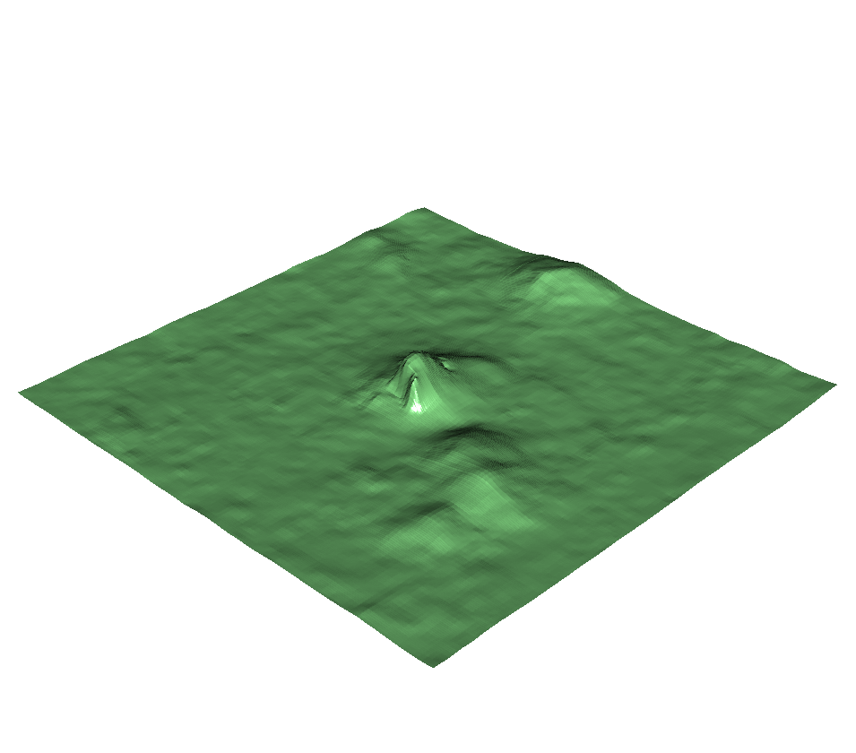

```r
library(quadmesh)

elevation_mesh <- quadmesh(tibrogargan_elevation)
rgl::shade3d(elevation_mesh, col = "light green")
```

## See Also

*ceramic - A wrapper for `quadmesh` + `slippymath` for making 3D surfaces textured with satellite tiles.